# Ad-ventures Online :)

## Intro to the Ad world

As we jump into the world of Ads, our curiosity grows - what makes an ad relevant, where do they thrive, and how do they capture our attention? Join me as I explore each world, creating a bigger insight for our knowledge. Lets go!

[figure not shown]

Cat meme

## Is it Irrelevant :(

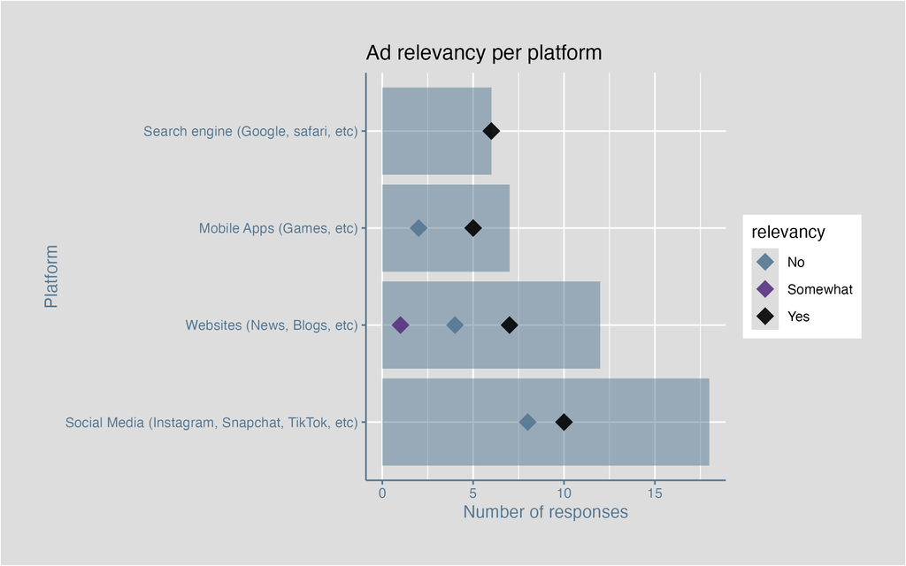

Our first stop is the world of ad relevancy, and we’ve got some good news!!!

When we view our relevancy points, ads are often much more relevant than not- a win-win situation for advertisers and viewers <sub>yay!</sub>.

Interestingly, social media serves a much higher volume of ads than any other platform. However, it’s search engines that consistently deliver the most relevant ads.

Why do you think that is? An explanation could be the specific tailoring our algorithm uses (since our searches tend to be so specific, the ads they serve are naturally more aligned with our interests).

## Combo??

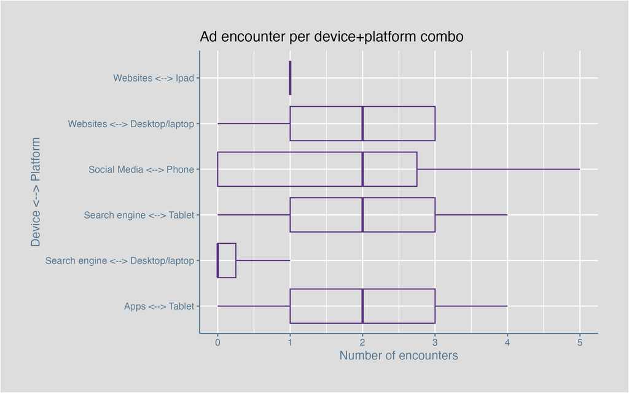

Next up, let’s explore the world of platform and device combos.

But here’s the real twist – the total number of encounters for each combo is pretty low, with the x-axis stopping at just 5. So, it seems we don’t see the same ad all that often, do we?

In fact, the average number of encounters per ad is just 2. This means algorithms are doing a pretty solid job of mixing things up for us while still keeping it relevant. Lucky us!

## Time change

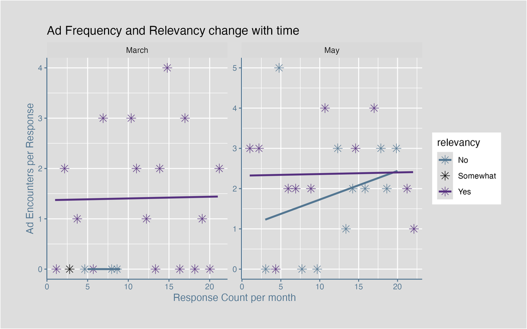

Observing the change of relevancy and encounter per month

Now that we have been through two worlds, lets explore the changes time has on ad encounter and relevancy.

In March, ads behaved differently. Encounters were generally more unique, with the maximum anyone reported seeing the same ad just 4 times. Plus, ads were overwhelmingly more relevant – a promising sign for both brands and audiences.

Fast forward to May, and the pattern has shifted. Ad encounters have grown a bit more repetitive, with the maximum number now reaching 5 (still very little but nonetheless) . But what really stands out is the sharp rise in ad irrelevancy, suggesting a noticeable drift from the more focused, personalized experience we saw earlier.

[figure not shown]

big cat diference